# CSCI E-63C Week 10 assignment

# Sub-problem 2 (15 points): effect of signal magnitude

For sample sizes of `nObs=200` and `1000` observations (approximately evenly split into training and test datasets) simulate data as shown above with average differences between the two classes that are same as above, half of that and twice that (`deltaClass=0.5`, `1` and `2`). Obtain and plot test error rates of random forest, LDA and KNN for each of the six (two samples sizes times three signal magnitudes) combinations of sample size and signal strengths. Describe the most pronounced differences across error rates for those datasets: does the increase in the number of observations impact the error rate of the models? Does change in the magnitude of signal impact their performance? Are different classifier approaches impacted in a similar way?

```r
dat200a <- genData(200,2,3,.5,c(10,25,50))
dat200b <- genData(200,2,3,1,c(10,25,50))
dat200c <- genData(200,2,3,2,c(10,25,50))

dat1000a <- genData(1000,2,3,.5,c(10,25,50))
dat1000b <- genData(1000,2,3,1,c(10,25,50))
dat1000c <- genData(1000,2,3,2,c(10,25,50))


q2.comb <- rbind(dat200a,dat200b,dat200c,dat1000a,dat1000b,dat1000c)

kable(q2.comb %>% dcast(type ~ nobs + dc, mean, value.var="err"))
```

| type | 200_0.5 | 200_1 | 200_2 | 1000_0.5 | 1000_1 | 1000_2 |
| --- | --- | --- | --- | --- | --- | --- |
| RF | 0.4907074 | 0.3956567 | 0.1797237 | 0.4752652 | 0.3152421 | 0.0584051 |
| LDA | 0.4931180 | 0.4928757 | 0.4980816 | 0.4960183 | 0.5087110 | 0.4973495 |
| K10 | 0.4854064 | 0.3564606 | 0.0732248 | 0.4680610 | 0.3134749 | 0.0538881 |
| K25 | 0.4861566 | 0.3810565 | 0.0736672 | 0.4658393 | 0.2983008 | 0.0504634 |
| K50 | 0.4923901 | 0.4676225 | 0.4493415 | 0.4678433 | 0.2948969 | 0.0489472 |

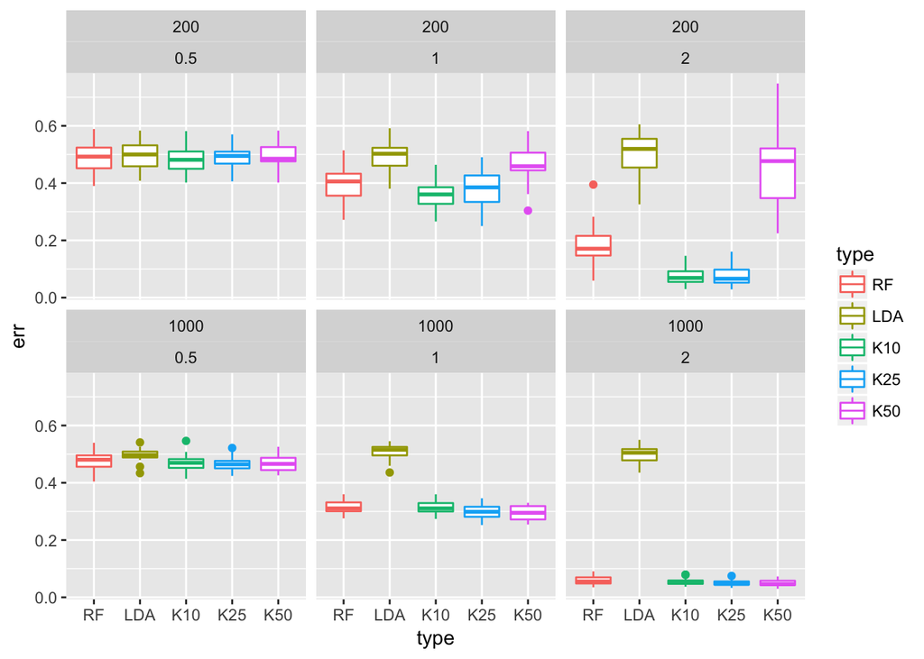

```r
ggplot(q2.comb,aes(x=type,y=err,colour=type)) + geom_boxplot() + facet_wrap(~nobs+dc, ncol=3)
```

```r
#The change in magnitude of the signals has a much bigger effect on reducing the error than increasing the number of observations. Both Random Forest and KNN were strongly impacted by the increase in signal magnitude. LDA is the clear outlier here: although an increase in observations led to a decrease in variance, increasing the signal magnitude had no noticable effect.

#For small values of n, Random Forest was a bit slower to decrease in error rates compared to KNN, however for large values of n, there seemed to be little difference between the two methods (test error rate of around 5%). The best error rates for both KNN and Random forest occured at large n and signal magnitudes of 2. It appears the increasing the number of observations minimized variance, and the increase of signal magnitude minimizes bias.
```

# Sub-problem 3 (15 points): varying counts of predictors

For all possible pairwise combinations of the numbers of variables associated with outcome (`nClassVars=2` and `5`) and those not associated with the outcome (`nNoiseVars=1`, `3` and `10`) – six pairwise combinations in total – obtain and present graphically test errors from random forest, LDA and KNN. Choose signal magnitude (`deltaClass`) so that it will yield non-trvial results – noticeable variability in the error rates across those six pairwise combinations of attribute counts. Describe the results: what is the impact of the increase of the number of attributes associated with the outcome on the classifier performance? What about the number of attributes not associated with outcome - does it affect classifier error rate? Are different classifier methods affected by these simulation parameters in a similar way?

```r
dat2a <- genData(1000,2, 1,2,c(10,25,50,100))
dat2b <- genData(1000,2, 3,2,c(10,25,50,100))
dat2c <- genData(1000,2,10,2,c(10,25,50,100))

dat5a <- genData(1000,5, 1,2,c(10,25,50,100))
dat5b <- genData(1000,5, 3,2,c(10,25,50,100))
dat5c <- genData(1000,5,10,2,c(10,25,50,100))

q3.comb <- rbind(dat2a,dat2b,dat2c,dat5a,dat5b,dat5c)

kable(q3.comb %>% dcast(type ~ ncvars + noisevars, mean, value.var="err"))
```

| type | 2_1 | 2_3 | 2_10 | 5_1 | 5_3 | 5_10 |
| --- | --- | --- | --- | --- | --- | --- |
| RF | 0.0488855 | 0.0563694 | 0.1394999 | 0.4886414 | 0.4941571 | 0.4938569 |
| LDA | 0.4766822 | 0.4987628 | 0.4918627 | 0.5017892 | 0.4929557 | 0.4940471 |
| K10 | 0.0463348 | 0.0490551 | 0.0624474 | 0.2020852 | 0.2198323 | 0.3067330 |
| K25 | 0.0440499 | 0.0464462 | 0.0547327 | 0.3567113 | 0.3862275 | 0.4497837 |
| K50 | 0.0441974 | 0.0465698 | 0.0531286 | 0.7007839 | 0.6791974 | 0.6507527 |
| K100 | 0.0452491 | 0.0459318 | 0.0573175 | 0.7243761 | 0.7111142 | 0.6578435 |

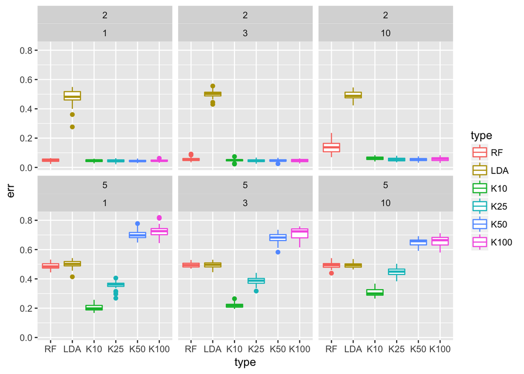

```r
ggplot(q3.comb,aes(x=type,y=err,colour=type)) + geom_boxplot() + facet_wrap(~ncvars+noisevars, ncol=3)
```

```r
#When the number of variables associated with the outcome is low (2), the performance of our methods is relatively stable even as we increase the number of noise variables. Random Forest seems to be affected by this as the variance and the bias are increased. KNN does not seem impacted by this, and LDA actually has smaller variance.

#when we increase the number of variables associated with the outcome to 5, all methods except LDA are affected. LDA seems largely robust to any of these changes, but the error rate is still equivelent to random guessing. The increase in the error rates is likely due to the effect of correlated variables on the different methods. The most highly impacted are KNN with large values of K. Random Forest does no worse than LDA. KNN for small values of k performs well, however we see that increasing the number of noise variables does cause the error rate to increase.


#
```

# Sub-problem 4: (15 points): effect of `mtry`

Parameter `mtry` in the call to `randomForest` defines the number of predictors randomly chosen to be evaluated for their association with the outcome at each split (please see help page for `randomForest` for more details). By default for classification problem it is set as square root of the number of predictors in the dataset. Here we will evaluate the impact of using different values of `mtry` on the error rate by random forest.

For `nObs=5000`, `deltaClass=2`, `nClassVars=3` and `nNoiseVars=20` generate data using the above approach and run `randomForest` on it with `mtry=2`, `5` and `10`. Describe the impact of using different values of `mtry` on the error rate by random forest and compare it to that by LDA/KNN.

```r
datmtry <- genData(5000,2,20,2,c(10,50,100),c(2,5,10))

kable(datmtry %>% group_by(type) %>% summarise(mean(err)))
```

| type | mean(err) |
| --- | --- |
| RF2 | 0.1456122 |
| RF5 | 0.0677494 |
| RF10 | 0.0538936 |
| LDA | 0.5019245 |
| K10 | 0.0622102 |
| K50 | 0.0492464 |
| K100 | 0.0485269 |

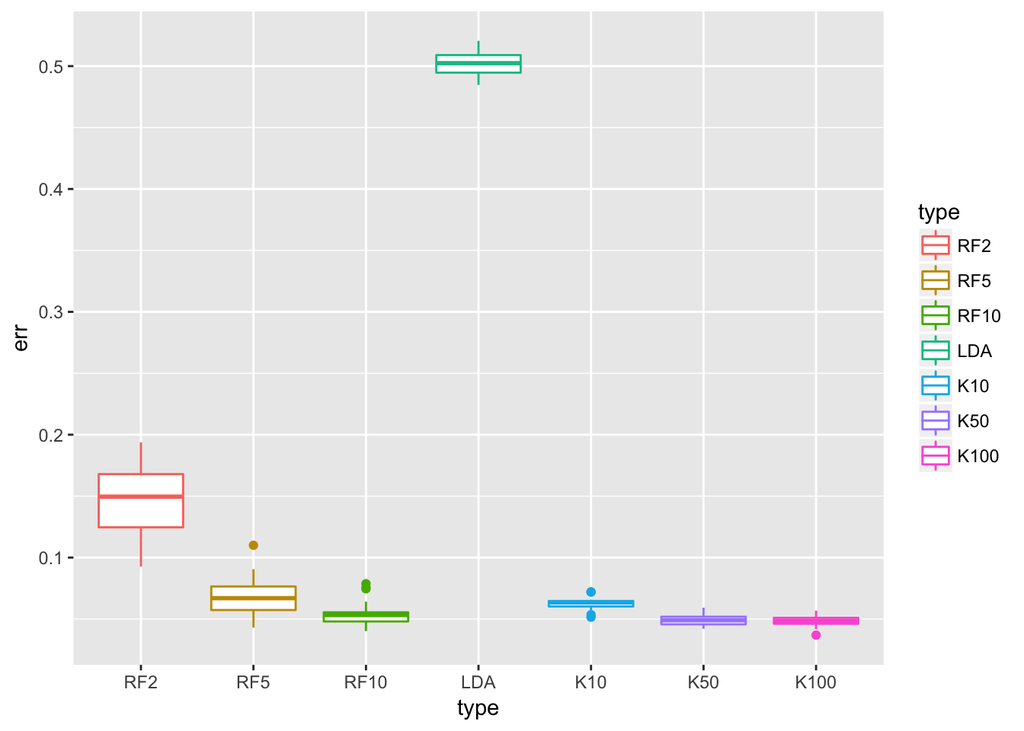

```r
ggplot(datmtry,aes(x=type,y=err,colour=type)) + geom_boxplot()
```

```r
#Increasing the number of predictors to randomly choose has both decreased the variance and improved the estimate for the Random Forest. The results observed for these values of mtry are still not quite as good as what was observed for KNN with large values of k, however we are still seeing a huge improvement over LDA which is about as good as guessing.
```